# AIML_ML_Project_2_full_code_Personal_Loan_Campaign

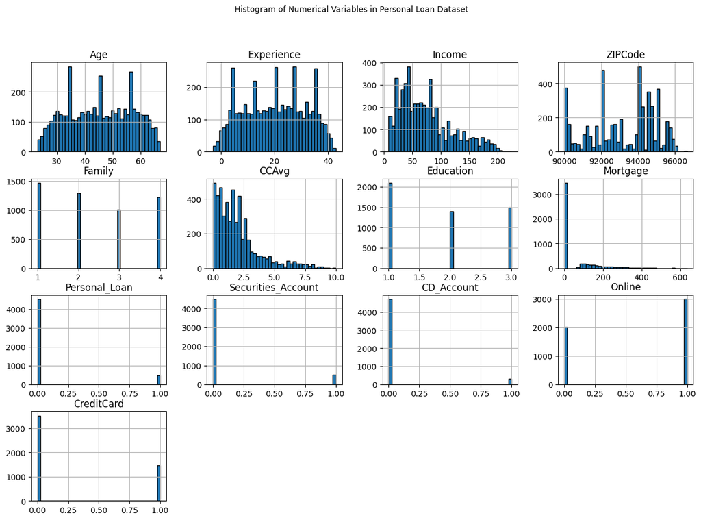

```python
#Histograms show the frequency distribution of numerical data.
# Plot histograms for all numerical columns
df.hist(figsize=(15, 10), bins=40, edgecolor="black")
plt.suptitle("Histogram of Numerical Variables in Personal Loan Dataset", fontsize=10)
plt.show()
```

```python
df.info()
```

```
<class 'pandas.core.frame.DataFrame'>
RangeIndex: 5000 entries, 0 to 4999
Data columns (total 13 columns):
 #   Column              Non-Null Count  Dtype
---  ------              --------------  -----
 0   Age                 5000 non-null   int64
 1   Experience          5000 non-null   int64
 2   Income              5000 non-null   int64
 3   ZIPCode             5000 non-null   int64
 4   Family              5000 non-null   int64
 5   CCAvg               5000 non-null   float64
 6   Education           5000 non-null   int64
 7   Mortgage            5000 non-null   int64
 8   Personal_Loan       5000 non-null   int64
 9   Securities_Account  5000 non-null   int64
 10  CD_Account          5000 non-null   int64
 11  Online              5000 non-null   int64
 12  CreditCard          5000 non-null   int64
dtypes: float64(1), int64(12)
memory usage: 507.9 KB
```

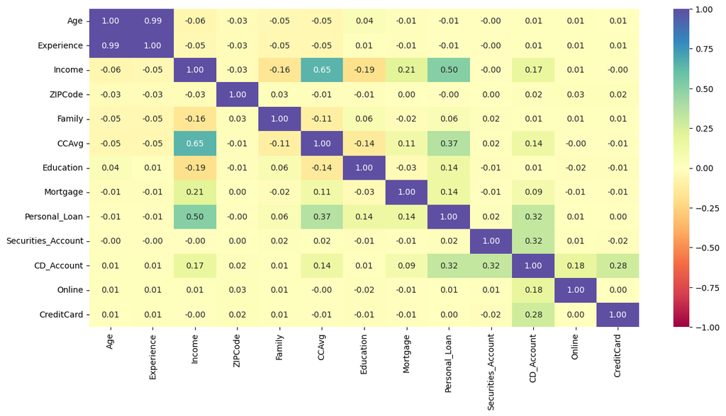

```python
# Plot the heatmap
columns_list = ['Age', 'Experience', 'Income', 'ZIPCode', 'Family', 'CCAvg', 'Education', 'Mortgage', 'Personal_Loan', 'Securities_Account', 'CD_Account', 'Online', 'CreditCard']
plt.figure(figsize=(15, 7))
sns.heatmap(df[columns_list].corr(numeric_only=True), annot=True, vmin=-1, vmax=1, fmt=".2f", cmap="Spectral")
plt.show()
```

```python
def stacked_barplot(data, predictor, target):
    count = data[predictor].nunique()
    sorter = data[target].value_counts().index[-1]

    # Create a crosstab of predictor vs target
    crosstab = pd.crosstab(data[predictor], data[target], margins=True).sort_values(
        by=sorter, ascending=False
    )
    print(crosstab)
    print("-" * 120)

    # Create a crosstab of predictor vs target againt to plot
    crosstab = pd.crosstab(data[predictor], data[target], normalize="index").sort_values(
            by=sorter, ascending=False
    )

    # Plot the stacked bar chart
    crosstab.plot(kind='bar', stacked=True, figsize=(count + 5, 5))

    # Display the plot
    plt.legend(loc="lower left", frameon=False)
    plt.legend(loc="upper left", bbox_to_anchor=(1, 1))

    plt.title(f"Stacked Bar Chart of {predictor} vs {target}")
    plt.xlabel(predictor)
    plt.ylabel(target)

    plt.show()
```

```
Personal_Loan     0    1   All
Education
All            4520  480  5000
3              1296  205  1501
2              1221  182  1403
1              2003   93  2096
------------------------------------------------------------------------------------------------------------------------
```

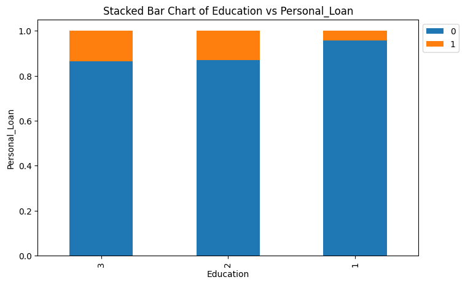

```python
stacked_barplot(df, "Education", "Personal_Loan")
```

```
Personal_Loan          0    1   All
Securities_Account
All                 4520  480  5000
0                   4058  420  4478
1                    462   60   522
------------------------------------------------------------------------------------------------------------------------
```

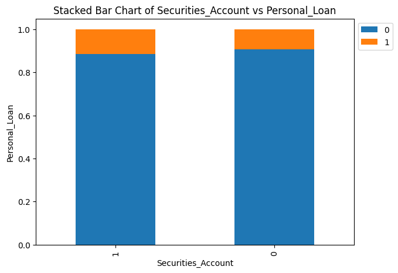

```python
stacked_barplot(df, "Securities_Account", "Personal_Loan")
```

```
Personal_Loan     0    1   All
CD_Account
All            4520  480  5000
0              4358  340  4698
1               162  140   302
------------------------------------------------------------------------------------------------------------------------
```

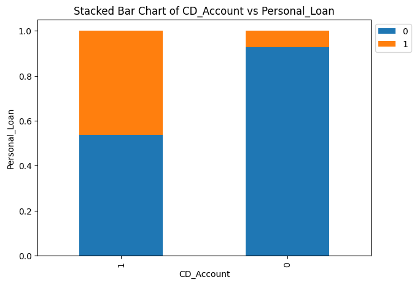

```python
stacked_barplot(df, "CD_Account", "Personal_Loan")
```

```
Personal_Loan     0    1   All
Online
All            4520  480  5000
1              2693  291  2984
0              1827  189  2016
------------------------------------------------------------------------------------------------------------------------
```

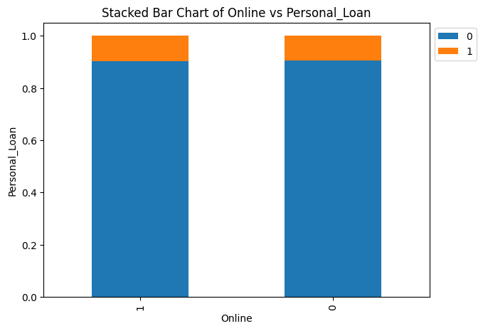

```python
stacked_barplot(df, "Online", "Personal_Loan")
```

```
Personal_Loan     0    1   All
CreditCard
All            4520  480  5000
0              3193  337  3530
1              1327  143  1470
------------------------------------------------------------------------------------------------------------------------
```

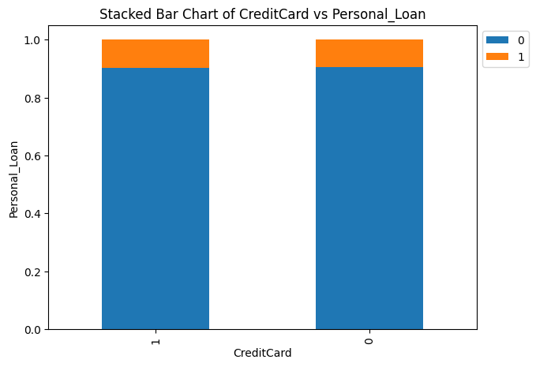

```python
stacked_barplot(df, "CreditCard", "Personal_Loan")
```

```
Personal_Loan     0    1   All
ZIPCode
All            4520  480  5000
94             1334  138  1472
92              894   94   988
95              735   80   815
90              636   67   703
91              510   55   565
93              374   43   417
96               37    3    40
------------------------------------------------------------------------------------------------------------------------
```

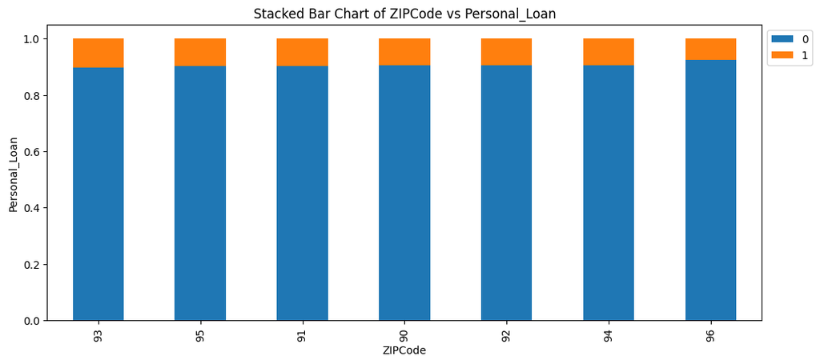

```python
stacked_barplot(df, "ZIPCode", "Personal_Loan")
```

```python
# funtion to plot distributions with respect to target
def plot_distributions(data, predictor, target):
    fig, axs = plt.subplots(2, 2, figsize=(12, 10))
    target_uniq = data[target].unique()

    axs[0, 0].set_title("Distribution of target for target=" + str(target_uniq[0]))
    axs[0, 0].set_xlabel(predictor)
    axs[0, 0].set_ylabel(target)
    sns.histplot(
        data=data[data[target] == target_uniq[0]],
        x=predictor,
        kde=True,
        ax=axs[0, 0],
        color="teal",
        stat="density",
    )

    axs[0, 1].set_title("Distribution of target for target=" + str(target_uniq[1]))
    axs[0, 1].set_xlabel(predictor)
    axs[0, 1].set_ylabel(target)
    sns.histplot(
        data=data[data[target] == target_uniq[1]],
        x=predictor,
        kde=True,
        ax=axs[0, 1],
        color="orange",
        stat="density",
    )

    axs[1, 0].set_title("Boxplot of " + predictor + " for target=" + str(target_uniq[0]))
    axs[1, 0].set_xlabel(predictor)
    axs[1, 0].set_ylabel(target)
    sns.boxplot(data=data[data[target] == target_uniq[0]],
                x=predictor,
                ax=axs[1, 0],
                palette="gist_rainbow"
    )

    axs[1, 1].set_title("Boxplot of " + predictor + " for target=" + str(target_uniq[1]))
    axs[1, 1].set_xlabel(predictor)
    axs[1, 1].set_ylabel(target)
    sns.boxplot(data=data[data[target] == target_uniq[1]],
                x=predictor,
                ax=axs[1, 1],
                showfliers=False,
                palette="gist_rainbow"
    )

    plt.tight_layout()
    plt.show()
```

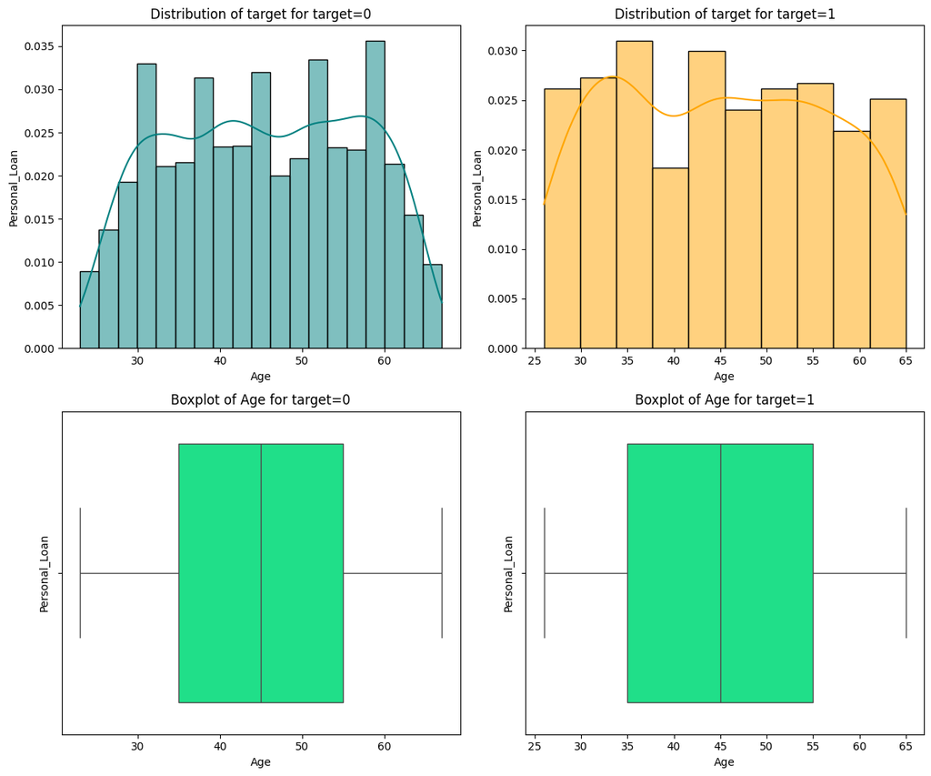

```python
plot_distributions(df, 'Age', 'Personal_Loan')
```

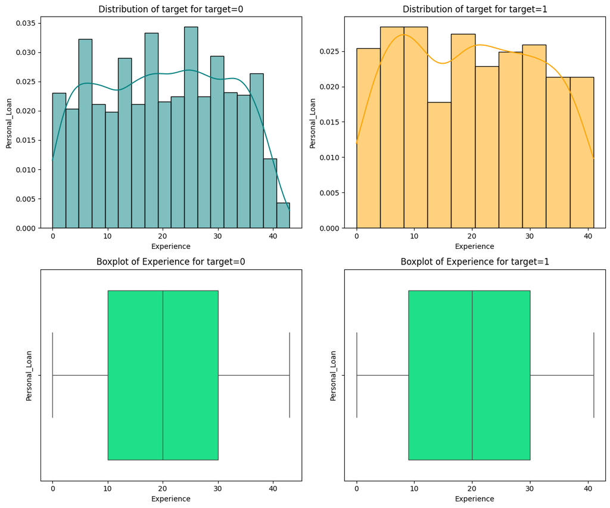

```python
plot_distributions(df, 'Experience', 'Personal_Loan')
```

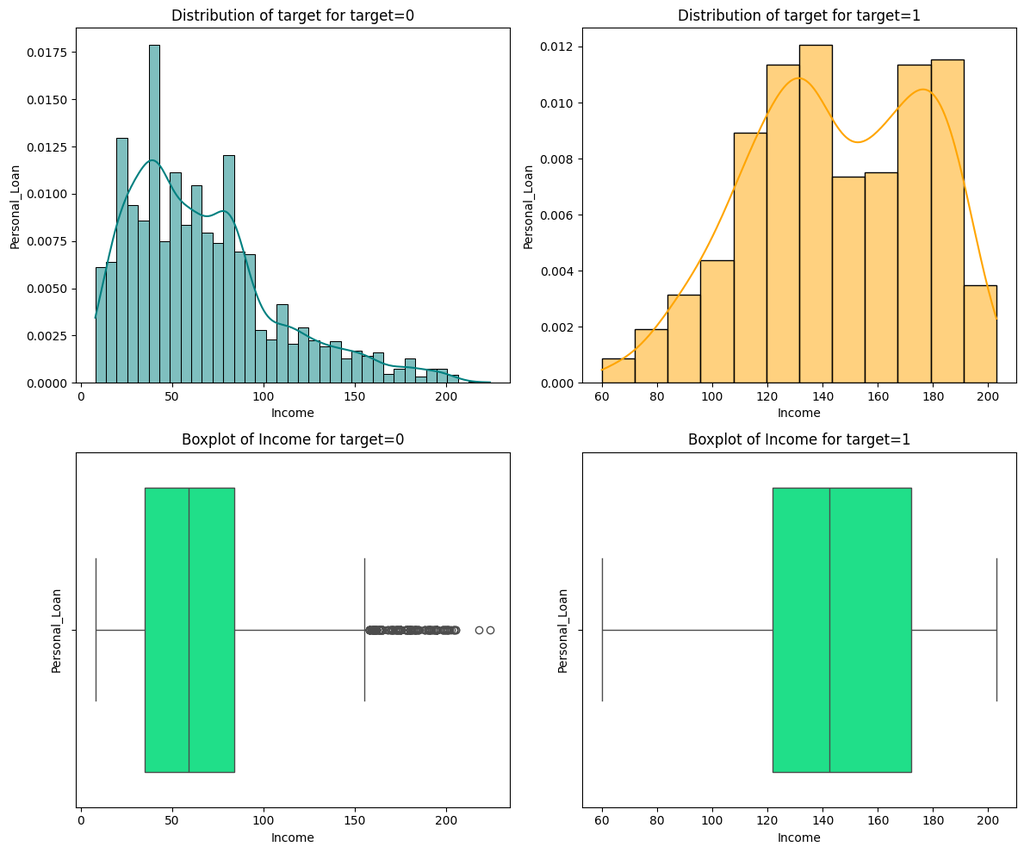

```python
plot_distributions(df, 'Income', 'Personal_Loan')
```

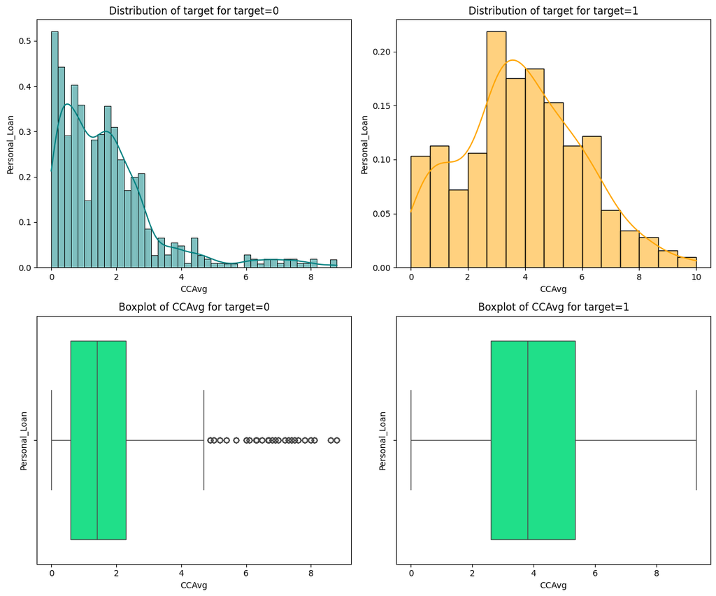

```python
plot_distributions(df, 'CCAvg', 'Personal_Loan')
```

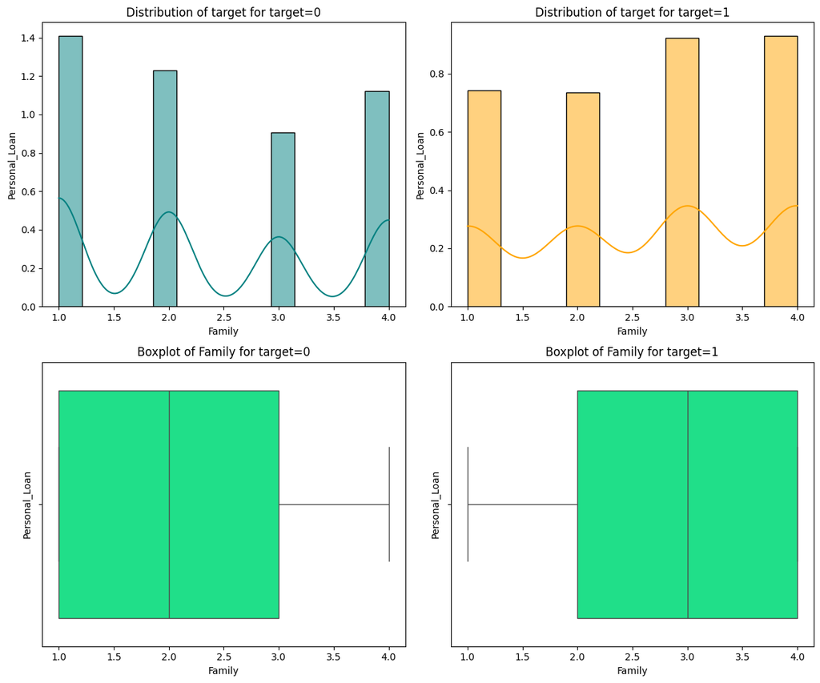

```python
plot_distributions(df, 'Family', 'Personal_Loan')
```

## Data Preprocessing

- Missing value treatment
- Feature engineering (if needed)
- Outlier detection and treatment (if needed)
- Preparing data for modeling
- Any other preprocessing steps (if needed)

### Outlier Detection

```python
Quantile1 = df.select_dtypes(include=["float64", "int64"]).quantile(0.25)  # To find the 25th percentile and 75th percentile.
Quantile3 = df.select_dtypes(include=["float64", "int64"]).quantile(0.75)

IQR = Quantile3 - Quantile1  # Inter Quantile Range (75th perentile - 25th percentile)

lower = (
    Quantile1 - 1.5 * IQR
)  # Finding lower and upper bounds for all values. All values outside these bounds are outliers
upper = Quantile3 + 1.5 * IQR

((df.select_dtypes(include=["float64", "int64"]) < lower)
    | (df.select_dtypes(include=["float64", "int64"]) > upper)
).sum() / len(df) * 100
```

|  | 0 |
| --- | --- |
| Age | 0.00 |
| Experience | 0.00 |
| Income | 1.92 |
| ZIPCode | 0.00 |
| Family | 0.00 |
| CCAvg | 6.48 |
| Education | 0.00 |
| Mortgage | 5.82 |
| Personal_Loan | 9.60 |
| Securities_Account | 10.44 |
| CD_Account | 6.04 |
| Online | 0.00 |
| CreditCard | 0.00 |

**dtype:** float64

### Checking for Anomalous Values

```python
# checking for experience <0
df[df["Experience"] < 0]["Experience"].unique()
```

```
array([-1, -2, -3])
```

```python
# Correcting the experience values
df["Experience"].replace(-1, 1, inplace=True)
df["Experience"].replace(-2, 2, inplace=True)
df["Experience"].replace(-3, 3, inplace=True)
# checking for experience <0
df[df["Experience"] < 0]["Experience"].unique()
```

```
array([], dtype=int64)
```

```python
df["Education"].unique()
```

```
array([1, 2, 3])
```

### Feature Engineering

```python
df["ZIPCode"] = df["ZIPCode"].astype(str)
print(
    "Number of unique values if we take first two digits of ZIPCode: ",
    df["ZIPCode"].str[0:2].nunique(),
)
df["ZIPCode"] = df["ZIPCode"].str[0:2]

df["ZIPCode"] = df["ZIPCode"].astype("category")
```

```
Number of unique values if we take first two digits of ZIPCode:  7
```

```python
df.head()
```

|  | Age | Experience | Income | ZIPCode | Family | CCAvg | Education | Mortgage | Personal_Loan | Securities_Account | CD_Account | Online | CreditCard |
| --- | --- | --- | --- | --- | --- | --- | --- | --- | --- | --- | --- | --- | --- |
| 0 | 25 | 1 | 49 | 91 | 4 | 1.6 | 1 | 0 | 0 | 1 | 0 | 0 | 0 |
| 1 | 45 | 19 | 34 | 90 | 3 | 1.5 | 1 | 0 | 0 | 1 | 0 | 0 | 0 |
| 2 | 39 | 15 | 11 | 94 | 1 | 1.0 | 1 | 0 | 0 | 0 | 0 | 0 | 0 |
| 3 | 35 | 9 | 100 | 94 | 1 | 2.7 | 2 | 0 | 0 | 0 | 0 | 0 | 0 |
| 4 | 35 | 8 | 45 | 91 | 4 | 1.0 | 2 | 0 | 0 | 0 | 0 | 0 | 1 |

```python
## Converting the data type of categorical features to 'category'
df.info()
cat_cols = [
    "Education",
    "Personal_Loan",
    "Securities_Account",
    "CD_Account",
    "Online",
    "CreditCard",
    "ZIPCode",
]
df[cat_cols] = df[cat_cols].astype("category")
df.info()
```

```
<class 'pandas.core.frame.DataFrame'>
RangeIndex: 5000 entries, 0 to 4999
Data columns (total 13 columns):
 #   Column              Non-Null Count  Dtype
---  ------              --------------  -----
 0   Age                 5000 non-null   int64
 1   Experience          5000 non-null   int64
 2   Income              5000 non-null   int64
 3   ZIPCode             5000 non-null   category
 4   Family              5000 non-null   int64
 5   CCAvg               5000 non-null   float64
 6   Education           5000 non-null   int64
 7   Mortgage            5000 non-null   int64
 8   Personal_Loan       5000 non-null   int64
 9   Securities_Account  5000 non-null   int64
 10  CD_Account          5000 non-null   int64
 11  Online              5000 non-null   int64
 12  CreditCard          5000 non-null   int64
dtypes: category(1), float64(1), int64(11)
memory usage: 474.1 KB
<class 'pandas.core.frame.DataFrame'>
RangeIndex: 5000 entries, 0 to 4999
Data columns (total 13 columns):
 #   Column              Non-Null Count  Dtype
---  ------              --------------  -----
 0   Age                 5000 non-null   int64
 1   Experience          5000 non-null   int64
 2   Income              5000 non-null   int64
 3   ZIPCode             5000 non-null   category
 4   Family              5000 non-null   int64
 5   CCAvg               5000 non-null   float64
 6   Education           5000 non-null   category
 7   Mortgage            5000 non-null   int64
 8   Personal_Loan       5000 non-null   category
 9   Securities_Account  5000 non-null   category
 10  CD_Account          5000 non-null   category
 11  Online              5000 non-null   category
 12  CreditCard          5000 non-null   category
dtypes: category(7), float64(1), int64(5)
memory usage: 269.8 KB
```

### Data Preparation for Modeling

```python
# dropping Experience as it is perfectly correlated with Age
X = df.drop(["Personal_Loan", "Experience"], axis=1)
Y = df["Personal_Loan"]

X = pd.get_dummies(X, columns=["ZIPCode", "Education"], drop_first=True)

X = X.astype(float)

# Splitting data in train and test sets
X_train, X_test, y_train, y_test = train_test_split(
    X, Y, test_size=0.30, random_state=1
)
```

```python
print("Shape of Training set : ", X_train.shape)
print("Shape of test set : ", X_test.shape)
print("Percentage of classes in training set:")
print(y_train.value_counts(normalize=True))
print("Percentage of classes in test set:")
print(y_test.value_counts(normalize=True))
```

```
Shape of Training set :  (3500, 17)
Shape of test set :  (1500, 17)
Percentage of classes in training set:
Personal_Loan
0    0.905429
1    0.094571
Name: proportion, dtype: float64
Percentage of classes in test set:
Personal_Loan
0    0.900667
1    0.099333
Name: proportion, dtype: float64
```

## Model Building

### Model Evaluation Criterion

First, let's create functions to calculate different metrics and confusion matrix so that we don't have to use the same code repeatedly for each model.

```python
def confusion_matrix_with_percentages(model, predictors, target):
    """To plot the confusion_matrix with percentages"""
    y_pred = model.predict(predictors)
    cm = confusion_matrix(target, y_pred)

    labels = np.asarray(
        [
            ["{0:0.0f}".format(item) + "\n{0:.2%}".format(item / cm.flatten().sum())]
            for item in cm.flatten()
        ]
    ).reshape(2, 2)

    plt.figure(figsize=(6, 4))
    plt.ylabel("True label")
    plt.xlabel("Predicted label")
    sns.heatmap(cm, annot=labels, fmt="")
```

### Model Building using Training Data

```python
model = DecisionTreeClassifier(criterion="gini", random_state=1)
model.fit(X_train, y_train)
```

```
DecisionTreeClassifier(random_state=1)
```

### Confusion Matrix with Percentages on Training Data

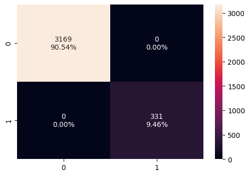

```python
# Checking model performance in confusion matrix with percentages on training data
confusion_matrix_with_percentages(model, X_train, y_train)
```

### Compute Different Metrics to check model performance

```python
# defining a function to compute different metrics to check performance of a classification model
def model_performance(model, predictors, target):
    """Function to compute different metrics to check classification model performance"""

    # predicting using the independent variables
    pred = model.predict(predictors)

    acc = accuracy_score(target, pred)  # to compute Accuracy
    recall = recall_score(target, pred)  # to compute Recall
    precision = precision_score(target, pred)  # to compute Precision
    f1 = f1_score(target, pred)  # to compute F1-score

    # creating a dataframe of metrics
    return pd.DataFrame(
        {"Accuracy": acc, "Recall": recall, "Precision": precision, "F1": f1,},
        index=[0],
    )
```

```python
decision_tree_performance_train = model_performance(model, X_train, y_train)
decision_tree_performance_train
```

|  | Accuracy | Recall | Precision | F1 |
| --- | --- | --- | --- | --- |
| 0 | 1.0 | 1.0 | 1.0 | 1.0 |

## Visualizing the Decision Tree

```python
feature_names = list(X_train.columns)
print(feature_names)
```

```
['Age', 'Income', 'Family', 'CCAvg', 'Mortgage', 'Securities_Account', 'CD_Account', 'Online', 'CreditCard', 'ZIPCode_91', 'ZIPCode_92', 'ZIPCode_93', 'ZIPCode_94', 'ZIPCode_95', 'ZIPCode_96', 'Education_2', 'Education_3']
```

```python
def plot_tree(model, feature_names):
    plt.figure(figsize=(20, 30))
    out = tree.plot_tree(
                  model,
                  feature_names=feature_names,
                  filled=True,
                  fontsize=9,
                  node_ids=False,
                  class_names=None,
    )

    # below code will add arrows to the decision tree split if they are missing
    for o in out:
        arrow = o.arrow_patch

        if arrow is not None:
            arrow.set_edgecolor("black")
            arrow.set_linewidth(1)
    plt.show()
```

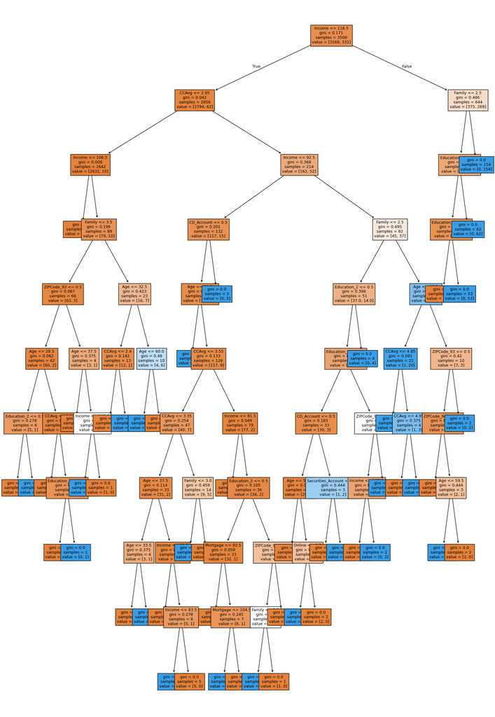

```python
plot_tree(model, feature_names)
```

```python
# Text report showing the rules of a decision tree -

print(tree.export_text(model, feature_names=feature_names, show_weights=True))
```

```
|--- Income <= 116.50
|   |--- CCAvg <= 2.95
|   |   |--- Income <= 106.50
|   |   |   |--- weights: [2553.00, 0.00] class: 0
|   |   |--- Income >  106.50
|   |   |   |--- Family <= 3.50
|   |   |   |   |--- ZIPCode_93 <= 0.50
|   |   |   |   |   |--- Age <= 28.50
|   |   |   |   |   |   |--- Education_2 <= 0.50
|   |   |   |   |   |   |   |--- weights: [5.00, 0.00] class: 0
|   |   |   |   |   |   |--- Education_2 >  0.50
|   |   |   |   |   |   |   |--- weights: [0.00, 1.00] class: 1
|   |   |   |   |   |--- Age >  28.50
|   |   |   |   |   |   |--- CCAvg <= 2.20
|   |   |   |   |   |   |   |--- weights: [48.00, 0.00] class: 0
|   |   |   |   |   |   |--- CCAvg >  2.20
|   |   |   |   |   |   |   |--- Education_3 <= 0.50
|   |   |   |   |   |   |   |   |--- weights: [7.00, 0.00] class: 0
|   |   |   |   |   |   |   |--- Education_3 >  0.50
|   |   |   |   |   |   |   |   |--- weights: [0.00, 1.00] class: 1
|   |   |   |   |--- ZIPCode_93 >  0.50
|   |   |   |   |   |--- Age <= 37.50
|   |   |   |   |   |   |--- weights: [2.00, 0.00] class: 0
|   |   |   |   |   |--- Age >  37.50
|   |   |   |   |   |   |--- Income <= 112.00
|   |   |   |   |   |   |   |--- weights: [0.00, 1.00] class: 1
|   |   |   |   |   |   |--- Income >  112.00
|   |   |   |   |   |   |   |--- weights: [1.00, 0.00] class: 0
|   |   |   |--- Family >  3.50
|   |   |   |   |--- Age <= 32.50
|   |   |   |   |   |--- CCAvg <= 2.40
|   |   |   |   |   |   |--- weights: [12.00, 0.00] class: 0
|   |   |   |   |   |--- CCAvg >  2.40
|   |   |   |   |   |   |--- weights: [0.00, 1.00] class: 1
|   |   |   |   |--- Age >  32.50
|   |   |   |   |   |--- Age <= 60.00
|   |   |   |   |   |   |--- weights: [0.00, 6.00] class: 1
|   |   |   |   |   |--- Age >  60.00
|   |   |   |   |   |   |--- weights: [4.00, 0.00] class: 0
|   |--- CCAvg >  2.95
```

[output cut: 90 more lines]

```
|   |   |   |   |   |   |   |--- Age >  59.50
|   |   |   |   |   |   |   |   |--- weights: [2.00, 0.00] class: 0
|   |   |   |   |   |--- ZIPCode_93 >  0.50
|   |   |   |   |   |   |--- weights: [0.00, 2.00] class: 1
|--- Income >  116.50
|   |--- Family <= 2.50
|   |   |--- Education_3 <= 0.50
|   |   |   |--- Education_2 <= 0.50
|   |   |   |   |--- weights: [375.00, 0.00] class: 0
|   |   |   |--- Education_2 >  0.50
|   |   |   |   |--- weights: [0.00, 53.00] class: 1
|   |   |--- Education_3 >  0.50
|   |   |   |--- weights: [0.00, 62.00] class: 1
|   |--- Family >  2.50
|   |   |--- weights: [0.00, 154.00] class: 1
```

```python
# The importance of a feature in the tree building is computed as the
# (normalized) total reduction of the criterion brought by that feature.
# It is also known as the Gini importance
print(pd.DataFrame(model.feature_importances_,
                   columns=["Imp"],
                   index=X_train.columns
    ).sort_values(by="Imp",
                  ascending=False)
)
```

```
                         Imp
Income              0.308098
Family              0.259255
Education_2         0.166192
Education_3         0.147127
CCAvg               0.048798
Age                 0.033150
CD_Account          0.017273
ZIPCode_94          0.007183
ZIPCode_93          0.004682
Mortgage            0.003236
Online              0.002224
Securities_Account  0.002224
ZIPCode_91          0.000556
ZIPCode_92          0.000000
ZIPCode_95          0.000000
ZIPCode_96          0.000000
CreditCard          0.000000
```

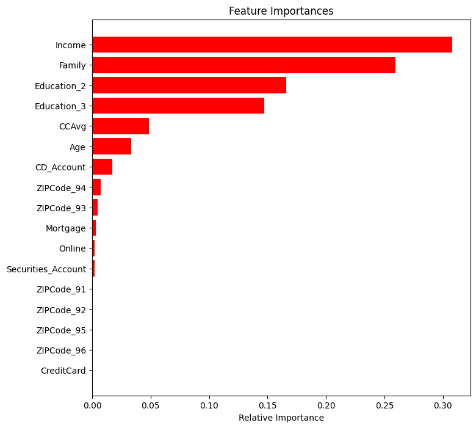

```python
importances = model.feature_importances_
indices = np.argsort(importances)

plt.figure(figsize=(8, 8))
plt.title("Feature Importances")
plt.barh(range(len(indices)),
         importances[indices],
         color="Red",
         align="center")
plt.yticks(range(len(indices)), [feature_names[i] for i in indices])
plt.xlabel("Relative Importance")
plt.show()
```

### Checking Model Performance on Test Data

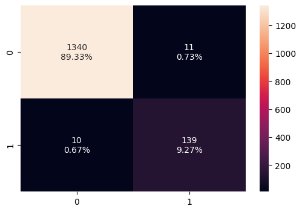

```python
# Checking model performance in confusion matrix with percentages on training data
confusion_matrix_with_percentages(model, X_test, y_test)
```

### Compute Different Metrics to check model performance on Test Data

```python
decision_tree_performance_test = model_performance(model, X_test, y_test)
decision_tree_performance_test
```

|  | Accuracy | Recall | Precision | F1 |
| --- | --- | --- | --- | --- |
| 0 | 0.986 | 0.932886 | 0.926667 | 0.929766 |

## Model Performance Improvement

### Pre-Pruning the Decision Tree

```python
# Define the parameters of the tree to iterate over
max_depth_values = np.arange(2, 11, 2)
max_leaf_nodes_values = [50, 75, 100, 150, 200]
min_samples_split_values = [10, 30, 50, 70, 90]

# Initialize variables to store the best model and its performance
best_estimator = None
best_score_diff = float('inf')
best_test_score = 0.0

# Iterate over all combinations of the specified parameter values
for max_depth in max_depth_values:
    for max_leaf_nodes in max_leaf_nodes_values:
        for min_samples_split in min_samples_split_values:

            # Initialize the tree with the current set of parameters
            estimator = DecisionTreeClassifier(
                max_depth=max_depth,
                max_leaf_nodes=max_leaf_nodes,
                min_samples_split=min_samples_split,
                class_weight='balanced',
                random_state=42
            )

            # Fit the model to the training data
            estimator.fit(X_train, y_train)

            # Make predictions on the training and test sets
            y_train_pred = estimator.predict(X_train)
            y_test_pred = estimator.predict(X_test)

            # Calculate recall scores for training and test sets
            train_recall_score = recall_score(y_train, y_train_pred)
            test_recall_score = recall_score(y_test, y_test_pred)

            # Calculate the absolute difference between training and test recall scores
            score_diff = abs(train_recall_score - test_recall_score)

            # Update the best estimator and best score if the current one has a smaller score difference
            if (score_diff < best_score_diff) & (test_recall_score > best_test_score):
                best_score_diff = score_diff
                best_test_score = test_recall_score
                best_estimator = estimator

# Print the best parameters
print("Best parameters found:")
print(f"Max depth: {best_estimator.max_depth}")
print(f"Max leaf nodes: {best_estimator.max_leaf_nodes}")
print(f"Min samples split: {best_estimator.min_samples_split}")
print(f"Best test recall score: {best_test_score}")
```

```
Best parameters found:
Max depth: 2
Max leaf nodes: 50
Min samples split: 10
Best test recall score: 1.0
```

```python
# Fit the best algorithm to the data.
best_estimator.fit(X_train, y_train, sample_weight=None, check_input=True)
```

```
DecisionTreeClassifier(class_weight='balanced', max_depth=2, max_leaf_nodes=50,
                       min_samples_split=10, random_state=42)
```

### Checking Model performance on Training Data

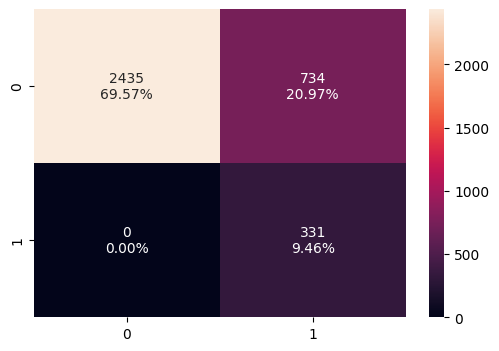

```python
confusion_matrix_with_percentages(best_estimator, X_train, y_train)
```

```python
# Check performance on Train Data
decisiontree_tune_perf_train = model_performance(best_estimator, X_train, y_train)
decisiontree_tune_perf_train
```

|  | Accuracy | Recall | Precision | F1 |
| --- | --- | --- | --- | --- |
| 0 | 0.790286 | 1.0 | 0.310798 | 0.474212 |

### Visualizing the Decision Tree

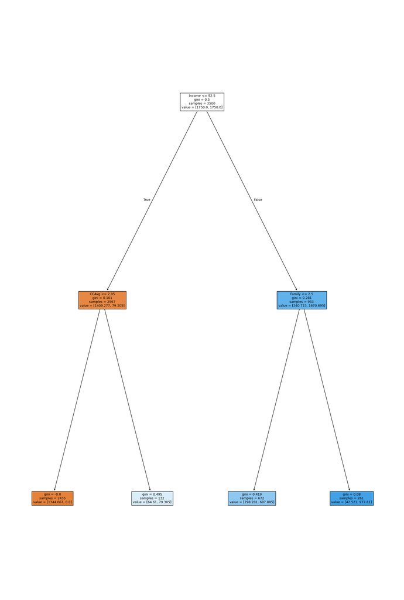

```python
plot_tree(best_estimator, feature_names)
```

```python
# Text report showing the rules of a decision tree -
print(tree.export_text(best_estimator,
                       feature_names=feature_names,
                       show_weights=True))
```

```
|--- Income <= 92.50
|   |--- CCAvg <= 2.95
|   |   |--- weights: [1344.67, 0.00] class: 0
|   |--- CCAvg >  2.95
|   |   |--- weights: [64.61, 79.31] class: 1
|--- Income >  92.50
|   |--- Family <= 2.50
|   |   |--- weights: [298.20, 697.89] class: 1
|   |--- Family >  2.50
|   |   |--- weights: [42.52, 972.81] class: 1
```

```python
print(pd.DataFrame(best_estimator.feature_importances_,
                   columns=["Imp"],
                   index=X_train.columns
     ).sort_values(by="Imp",
                   ascending=False))
```

```
                         Imp
Income              0.876529
CCAvg               0.066940
Family              0.056531
Age                 0.000000
ZIPCode_92          0.000000
Education_2         0.000000
ZIPCode_96          0.000000
ZIPCode_95          0.000000
ZIPCode_94          0.000000
ZIPCode_93          0.000000
CreditCard          0.000000
ZIPCode_91          0.000000
Online              0.000000
CD_Account          0.000000
Securities_Account  0.000000
Mortgage            0.000000
Education_3         0.000000
```

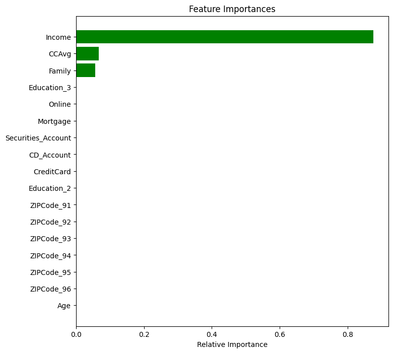

```python
importances = best_estimator.feature_importances_
indices = np.argsort(importances)

plt.figure(figsize=(8, 8))
plt.title("Feature Importances")
plt.barh(range(len(indices)), importances[indices], color="green", align="center")
plt.yticks(range(len(indices)), [feature_names[i] for i in indices])
plt.xlabel("Relative Importance")
plt.show()
```

### Checking performance on Test Data

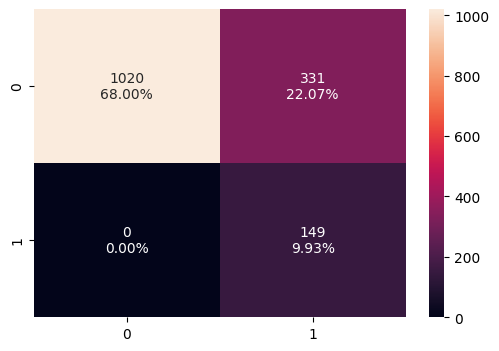

```python
confusion_matrix_with_percentages(best_estimator, X_test, y_test)
```

```python
# Check performance on Test Data
decisiontree_tune_perf_test = model_performance(best_estimator, X_test, y_test)
decisiontree_tune_perf_test
```

|  | Accuracy | Recall | Precision | F1 |
| --- | --- | --- | --- | --- |
| 0 | 0.779333 | 1.0 | 0.310417 | 0.473768 |

### Post Pruning the Decision Tree

- Cost complexity pruning provides another option to control the size of a tree.
- In `DecisionTreeClassifier`, this pruning technique is parameterized by the cost complexity parameter, `ccp_alpha`.
- Greater values of `ccp_alpha` increase the number of nodes pruned.
- Here we only show the effect of `ccp_alpha` on regularizing the trees and how to choose the optimal `ccp_alpha` value.

**Total impurity of leaves vs effective alphas of pruned tree**

Minimal cost complexity pruning recursively finds the node with the "weakest link". The weakest link is characterized by an effective alpha, where the nodes with the smallest effective alpha are pruned first. To get an idea of what values of `ccp_alpha` could be appropriate, scikit-learn provides `DecisionTreeClassifier.cost_complexity_pruning_path` that returns the effective alphas and the corresponding total leaf impurities at each step of the pruning process. As alpha increases, more of the tree is pruned, which increases the total impurity of its leaves.

```python
classifier = DecisionTreeClassifier(random_state=1)
pruning_path = classifier.cost_complexity_pruning_path(X_train, y_train)
ccp_alphas_train, impurities_train = pruning_path.ccp_alphas, pruning_path.impurities
pd.DataFrame(pruning_path)
```

|  | ccp_alphas | impurities |
| --- | --- | --- |
| 0 | 0.000000 | 0.000000 |
| 1 | 0.000186 | 0.001114 |
| 2 | 0.000214 | 0.001542 |
| 3 | 0.000242 | 0.002750 |
| 4 | 0.000250 | 0.003250 |
| 5 | 0.000268 | 0.004324 |
| 6 | 0.000272 | 0.004868 |
| 7 | 0.000276 | 0.005420 |
| 8 | 0.000381 | 0.005801 |
| 9 | 0.000527 | 0.006329 |
| 10 | 0.000625 | 0.006954 |
| 11 | 0.000700 | 0.007654 |
| 12 | 0.000769 | 0.010731 |
| 13 | 0.000882 | 0.014260 |
| 14 | 0.000889 | 0.015149 |
| 15 | 0.001026 | 0.017200 |
| 16 | 0.001305 | 0.018505 |
| 17 | 0.001647 | 0.020153 |
| 18 | 0.002333 | 0.022486 |
| 19 | 0.002407 | 0.024893 |
| 20 | 0.003294 | 0.028187 |
| 21 | 0.006473 | 0.034659 |
| 22 | 0.025146 | 0.084951 |
| 23 | 0.039216 | 0.124167 |
| 24 | 0.047088 | 0.171255 |

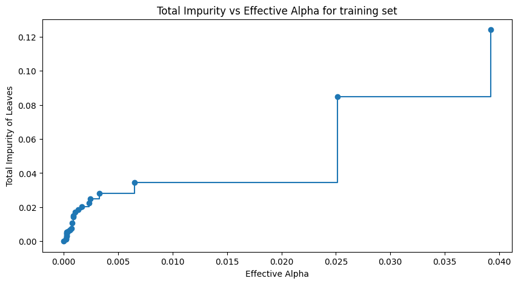

```python
# For Training set
fig, ax = plt.subplots(figsize=(10, 5))
ax.plot(ccp_alphas_train[:-1],
        impurities_train[:-1],
        marker="o",
        drawstyle="steps-post")
ax.set_xlabel("Effective Alpha")
ax.set_ylabel("Total Impurity of Leaves")
ax.set_title("Total Impurity vs Effective Alpha for training set")
plt.show()
```

```python
# Train decision tree using effective alphas
# The last value in ccp_alphas is the alpha value that prunes the whole tree,
# leaving the tree, clfs_train[-1], with one node
clfs_train = []
for ccp_alpha_train in ccp_alphas_train:
    clf_train = DecisionTreeClassifier(random_state=1,
                                       ccp_alpha=ccp_alpha_train)
    clf_train.fit(X_train, y_train)
    clfs_train.append(clf_train)
print(
    "Number of nodes in the last tree is: {} with ccp_alpha_train: {}".format(
        clfs_train[-1].tree_.node_count, ccp_alphas_train[-1]
    )
)
```

```
Number of nodes in the last tree is: 1 with ccp_alpha_train: 0.04708834100596766
```

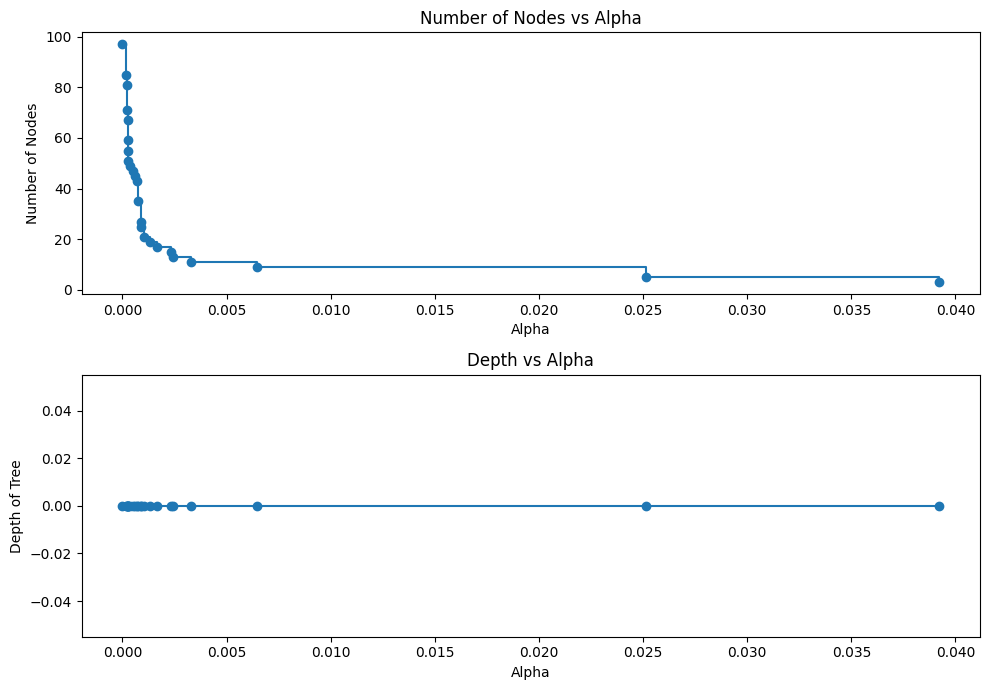

```python
clfs_train = clfs_train[:-1]
ccp_alphas_train = ccp_alphas_train[:-1]

node_counts = [clf_train.tree_.node_count for clf_train in clfs_train]
depth = [clf_train.tree_.max_depth for clf in clfs_train]
fig, ax = plt.subplots(2, 1, figsize=(10, 7))

ax[0].plot(ccp_alphas_train,
           node_counts,
           marker="o",
           drawstyle="steps-post")
ax[0].set_xlabel("Alpha")
ax[0].set_ylabel("Number of Nodes")
ax[0].set_title("Number of Nodes vs Alpha")

ax[1].plot(ccp_alphas_train,
           depth, marker="o",
           drawstyle="steps-post")
ax[1].set_xlabel("Alpha")
ax[1].set_ylabel("Depth of Tree")
ax[1].set_title("Depth vs Alpha")
fig.tight_layout()
```

### Recall vs Alpha for Training & Testing Sets

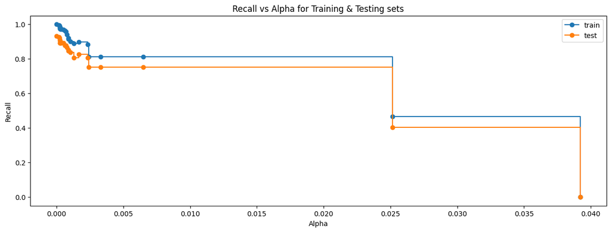

```python
recall_train = []
recall_test = []
for clf_train in clfs_train:
    pred_train = clf_train.predict(X_train)
    values_train = recall_score(y_train, pred_train)
    recall_train.append(values_train)

    pred_test = clf_train.predict(X_test)
    values_test = recall_score(y_test, pred_test)
    recall_test.append(values_test)

fig, ax = plt.subplots(figsize=(15, 5))
ax.set_xlabel("Alpha")
ax.set_ylabel("Recall")
ax.set_title("Recall vs Alpha for Training & Testing sets")
ax.plot(ccp_alphas_train,
        recall_train,
        marker="o",
        label="train",
        drawstyle="steps-post")
ax.plot(ccp_alphas_train,
        recall_test,
        marker="o",
        label="test",
        drawstyle="steps-post")
ax.legend()
plt.show()
```

```python
print('Recall Test :')
print(recall_test)

for i in range(len(clfs_train)):
    print(clfs_train[i])
index_best_model = np.argmax(recall_test)
best_model = clfs_train[index_best_model]
print('--------------------------------------------------------------------------')
print('Best Model :')
print(best_model)
```

```
Recall Test :
[0.9328859060402684, 0.9261744966442953, 0.9194630872483222, 0.9060402684563759, 0.9060402684563759, 0.8926174496644296, 0.8926174496644296, 0.8926174496644296, 0.8926174496644296, 0.8926174496644296, 0.8791946308724832, 0.8791946308724832, 0.8657718120805369, 0.8523489932885906, 0.8456375838926175,…
DecisionTreeClassifier(random_state=1)
DecisionTreeClassifier(ccp_alpha=0.00018565400843881868, random_state=1)
DecisionTreeClassifier(ccp_alpha=0.00021428571428571427, random_state=1)
DecisionTreeClassifier(ccp_alpha=0.00024155844155844173, random_state=1)
DecisionTreeClassifier(ccp_alpha=0.00025, random_state=1)
DecisionTreeClassifier(ccp_alpha=0.00026839826839826833, random_state=1)
DecisionTreeClassifier(ccp_alpha=0.00027210884353741507, random_state=1)
DecisionTreeClassifier(ccp_alpha=0.00027619047619047604, random_state=1)
DecisionTreeClassifier(ccp_alpha=0.0003809523809523809, random_state=1)
DecisionTreeClassifier(ccp_alpha=0.0005274725274725272, random_state=1)
DecisionTreeClassifier(ccp_alpha=0.0006251082251082257, random_state=1)
DecisionTreeClassifier(ccp_alpha=0.0007000000000000001, random_state=1)
DecisionTreeClassifier(ccp_alpha=0.0007692062082573395, random_state=1)
DecisionTreeClassifier(ccp_alpha=0.0008822052285337754, random_state=1)
DecisionTreeClassifier(ccp_alpha=0.0008888888888888888, random_state=1)
DecisionTreeClassifier(ccp_alpha=0.0010255748979153235, random_state=1)
DecisionTreeClassifier(ccp_alpha=0.0013054413254663562, random_state=1)
DecisionTreeClassifier(ccp_alpha=0.0016474873820495938, random_state=1)
DecisionTreeClassifier(ccp_alpha=0.002333060640147255, random_state=1)
DecisionTreeClassifier(ccp_alpha=0.0024071608186941196, random_state=1)
DecisionTreeClassifier(ccp_alpha=0.003293801935470502, random_state=1)
DecisionTreeClassifier(ccp_alpha=0.006472814718223811, random_state=1)
DecisionTreeClassifier(ccp_alpha=0.02514577259475219, random_state=1)
DecisionTreeClassifier(ccp_alpha=0.03921599695778932, random_state=1)
--------------------------------------------------------------------------
Best Model :
DecisionTreeClassifier(random_state=1)
```

```python
estimator2 = DecisionTreeClassifier(ccp_alpha=0.00027210884353741507,
                                    class_weight={0: 0.15, 1: 0.85},
                                    random_state=1 )
estimator2.fit(X_train, y_train)
```

```
DecisionTreeClassifier(ccp_alpha=0.00027210884353741507,
                       class_weight={0: 0.15, 1: 0.85}, random_state=1)
```

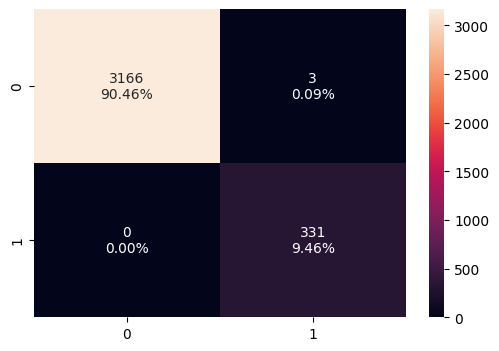

```python
# Checking performance on Training Data
confusion_matrix_with_percentages(estimator2, X_train, y_train)
```

```python
# Check performance on Train data
decisiontree_tune_post_train = model_performance(estimator2, X_train, y_train)
decisiontree_tune_post_train
```

|  | Accuracy | Recall | Precision | F1 |
| --- | --- | --- | --- | --- |
| 0 | 0.999143 | 1.0 | 0.991018 | 0.995489 |

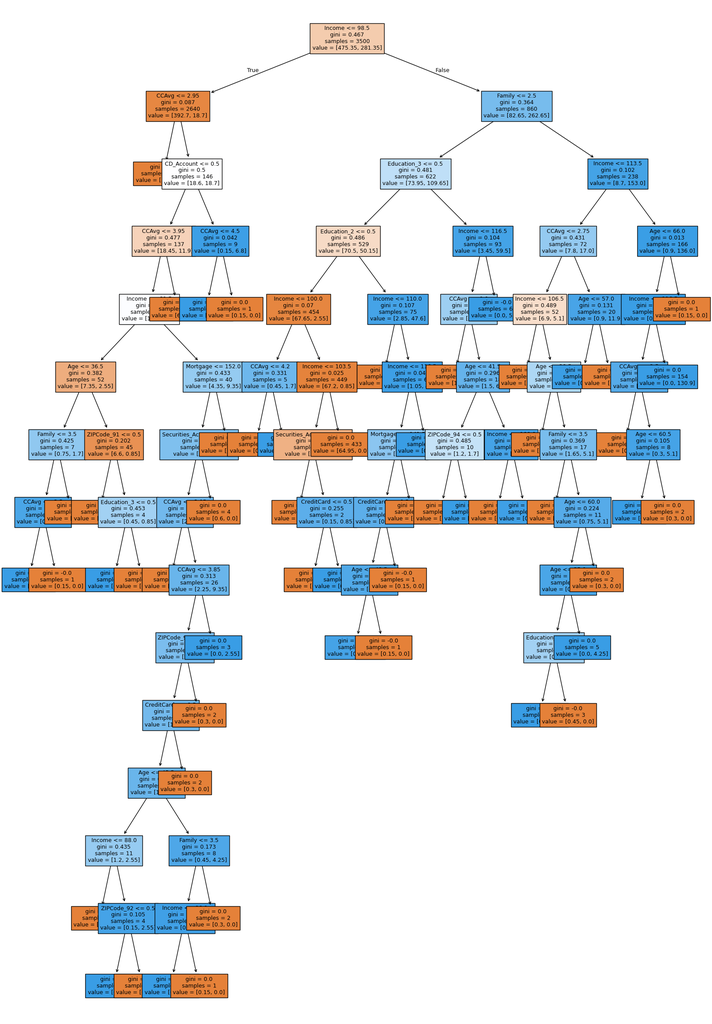

```python
#Visualizing Decision Tree
plot_tree(estimator2, feature_names)
```

```python
# Text report showing rules of decision tree
print(tree.export_text(estimator2,
                       feature_names=feature_names,
                       show_weights=True))
```

```
|--- Income <= 98.50
|   |--- CCAvg <= 2.95
|   |   |--- weights: [374.10, 0.00] class: 0
|   |--- CCAvg >  2.95
|   |   |--- CD_Account <= 0.50
|   |   |   |--- CCAvg <= 3.95
|   |   |   |   |--- Income <= 81.50
|   |   |   |   |   |--- Age <= 36.50
|   |   |   |   |   |   |--- Family <= 3.50
|   |   |   |   |   |   |   |--- CCAvg <= 3.50
|   |   |   |   |   |   |   |   |--- weights: [0.00, 1.70] class: 1
|   |   |   |   |   |   |   |--- CCAvg >  3.50
|   |   |   |   |   |   |   |   |--- weights: [0.15, 0.00] class: 0
|   |   |   |   |   |   |--- Family >  3.50
|   |   |   |   |   |   |   |--- weights: [0.60, 0.00] class: 0
|   |   |   |   |   |--- Age >  36.50
|   |   |   |   |   |   |--- ZIPCode_91 <= 0.50
|   |   |   |   |   |   |   |--- weights: [6.15, 0.00] class: 0
|   |   |   |   |   |   |--- ZIPCode_91 >  0.50
|   |   |   |   |   |   |   |--- Education_3 <= 0.50
|   |   |   |   |   |   |   |   |--- weights: [0.00, 0.85] class: 1
|   |   |   |   |   |   |   |--- Education_3 >  0.50
|   |   |   |   |   |   |   |   |--- weights: [0.45, 0.00] class: 0
|   |   |   |   |--- Income >  81.50
|   |   |   |   |   |--- Mortgage <= 152.00
|   |   |   |   |   |   |--- Securities_Account <= 0.50
|   |   |   |   |   |   |   |--- CCAvg <= 3.05
|   |   |   |   |   |   |   |   |--- weights: [0.45, 0.00] class: 0
|   |   |   |   |   |   |   |--- CCAvg >  3.05
|   |   |   |   |   |   |   |   |--- CCAvg <= 3.85
|   |   |   |   |   |   |   |   |   |--- ZIPCode_91 <= 0.50
|   |   |   |   |   |   |   |   |   |   |--- CreditCard <= 0.50
|   |   |   |   |   |   |   |   |   |   |   |--- truncated branch of depth 4
|   |   |   |   |   |   |   |   |   |   |--- CreditCard >  0.50
|   |   |   |   |   |   |   |   |   |   |   |--- weights: [0.30, 0.00] class: 0
|   |   |   |   |   |   |   |   |   |--- ZIPCode_91 >  0.50
|   |   |   |   |   |   |   |   |   |   |--- weights: [0.30, 0.00] class: 0
|   |   |   |   |   |   |   |   |--- CCAvg >  3.85
|   |   |   |   |   |   |   |   |   |--- weights: [0.00, 2.55] class: 1
|   |   |   |   |   |   |--- Securities_Account >  0.50
```

[output cut: 90 more lines]

```
|   |   |   |   |   |--- weights: [0.75, 0.00] class: 0
|   |   |--- Income >  113.50
|   |   |   |--- Age <= 66.00
|   |   |   |   |--- Income <= 116.50
|   |   |   |   |   |--- CCAvg <= 2.50
|   |   |   |   |   |   |--- weights: [0.45, 0.00] class: 0
|   |   |   |   |   |--- CCAvg >  2.50
|   |   |   |   |   |   |--- Age <= 60.50
|   |   |   |   |   |   |   |--- weights: [0.00, 5.10] class: 1
|   |   |   |   |   |   |--- Age >  60.50
|   |   |   |   |   |   |   |--- weights: [0.30, 0.00] class: 0
|   |   |   |   |--- Income >  116.50
|   |   |   |   |   |--- weights: [0.00, 130.90] class: 1
|   |   |   |--- Age >  66.00
|   |   |   |   |--- weights: [0.15, 0.00] class: 0
```

```python
print(pd.DataFrame(
         estimator2.feature_importances_,
         columns=["Imp"],
         index=X_train.columns
     ).sort_values(by="Imp",
                   ascending=False)
)
```

```
                         Imp
Income              0.598659
Education_2         0.138693
CCAvg               0.078911
Education_3         0.067460
Family              0.066408
Age                 0.018238
CD_Account          0.011027
Mortgage            0.005053
Securities_Account  0.004728
ZIPCode_94          0.003990
ZIPCode_91          0.003596
CreditCard          0.002434
ZIPCode_92          0.000804
Online              0.000000
ZIPCode_93          0.000000
ZIPCode_95          0.000000
ZIPCode_96          0.000000
```

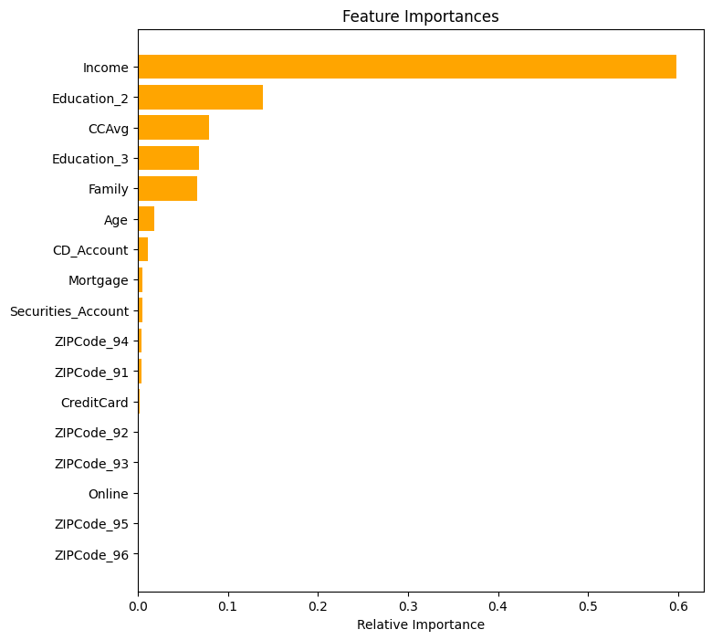

```python
importances = estimator2.feature_importances_
indices = np.argsort(importances)

plt.figure(figsize=(8, 8))
plt.title("Feature Importances")
plt.barh(range(len(indices)),
         importances[indices],
         color="orange",
         align="center")
plt.yticks(range(len(indices)),
           [feature_names[i] for i in indices])
plt.xlabel("Relative Importance")
plt.show()
```

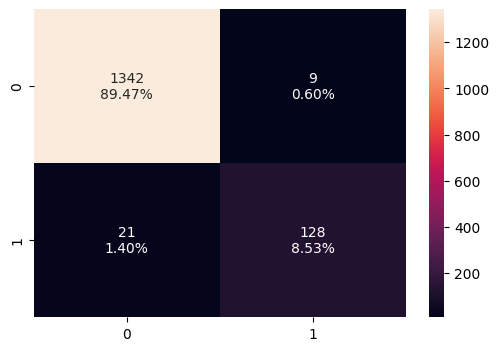

```python
# Checking performance on Test Data
confusion_matrix_with_percentages(estimator2, X_test, y_test)
```

```python
decisiontree_tune_post_test = model_performance(estimator2, X_test, y_test)
decisiontree_tune_post_test
```

|  | Accuracy | Recall | Precision | F1 |
| --- | --- | --- | --- | --- |
| 0 | 0.98 | 0.85906 | 0.934307 | 0.895105 |

## Model Performance Comparison and Final Model Selection

```python
# Training Data performance comparison
models_train_comp_df = pd.concat([decision_tree_performance_train.T,
                                  decisiontree_tune_perf_train.T,
                                  decisiontree_tune_post_train.T], axis=1,
)
models_train_comp_df.columns = ["Decision Tree (sklearn default)",
                                "Decision Tree (Pre-Pruning)",
                                "Decision Tree (Post-Pruning)"]

print("Training performance comparison:")
models_train_comp_df
```

```
Training performance comparison:
```

|  | Decision Tree (sklearn default) | Decision Tree (Pre-Pruning) | Decision Tree (Post-Pruning) |
| --- | --- | --- | --- |
| Accuracy | 1.0 | 0.790286 | 0.999143 |
| Recall | 1.0 | 1.000000 | 1.000000 |
| Precision | 1.0 | 0.310798 | 0.991018 |
| F1 | 1.0 | 0.474212 | 0.995489 |

```python
# Testing Data performance comparison
models_test_comp_df = pd.concat([decision_tree_performance_test.T,
                                 decisiontree_tune_perf_test.T,
                                 decisiontree_tune_post_test.T], axis=1,
)
models_test_comp_df.columns = ["Decision Tree (sklearn default)",
                                "Decision Tree (Pre-Pruning)",
                                "Decision Tree (Post-Pruning)"]

print("Testing performance comparison:")
models_test_comp_df
```

```
Testing performance comparison:
```

|  | Decision Tree (sklearn default) | Decision Tree (Pre-Pruning) | Decision Tree (Post-Pruning) |
| --- | --- | --- | --- |
| Accuracy | 0.986000 | 0.779333 | 0.980000 |
| Recall | 0.932886 | 1.000000 | 0.859060 |
| Precision | 0.926667 | 0.310417 | 0.934307 |
| F1 | 0.929766 | 0.473768 | 0.895105 |

## Actionable Insights and Business Recommendations

- What recommedations would you suggest to the bank?
- Decision tree with pre-pruning is giving the highest recall on the test set.
- The tree with pre pruning is not complex and easy to interpret.
- Income, CCAvg, and Family (in that order) are the top 3 most important features in identifying the potential customers who have a higher probability of purchasing the loan.
- Customers with Income range from 125 to 175, CCAvg between 3 and 5, Family from 2 and 4 have more chances to purchase the loan
- Customers who has CD_Account are having more chances to take a loan